# Майнор "Интеллектуальный анализ данных"

# Курс "Современные методы машинного обучения"

# Лабораторная работа №2. Детектирование букв.

Вам дано два датасета: train.csv и test.csv. Каждая строчка в файлах - это одна картинка с буквой, в строчке 785 элементов, первый элемент - класс, все остальные - картинка 28х28:

```python
import pandas as pd
#train = pd.read_csv("train.csv", header=None)
```

```python
from google.colab import files
#uploaded = files.upload()
import io
#test = pd.read_csv(io.BytesIO(uploaded['test.csv']), header=None)
test = pd.read_csv('test.csv', header=None)
```

```python
from google.colab import files
#uploaded = files.upload()
import io
#train =  pd.read_csv(io.BytesIO(uploaded['train.csv']), header=None)
train = pd.read_csv('train.csv', header=None)
```

```python
import numpy as np
train = np.asarray(train)
test = np.asarray(test)
first_pic = train[8]
pic_label, pic = first_pic[0], first_pic[1:]
print(pic_label)
```

```
7
```

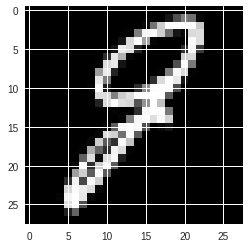

```python
%matplotlib inline
import matplotlib.pyplot as plt

plt.imshow(pic.reshape((28, 28)).T, cmap='gray')
plt.show()
```

a, b, c, d, e, f, g - 7ая буква английского алфавита.

## Задание

1) Создать модель нейронной сети, которая предсказывает букву по картинке. Модель обучать на данных из train.csv, качество модели проверять на данных из файла test.csv. Для построения модели желательно использовать библиотеки tensorflow и keras.

```
1. Обязательно : построить модели с 2мя и 3мя скрытыми слоями, количество нейронов в слоях подобрать таким, какое вы считаете необходимым (по результатам обучения).
2. Объяснить выбор оптимальных параметров нейронной сети - количество и состав слоёв, нейронов на каждом слое, функций активации и других параметров. (3 балла за пункты 1-2)
3. По желанию: попробовать другие возможные архитектуры (большее/меньшее количество слоёв, нейронов, свёрточные слои) с объяснением выбора и указанием получившихся результатов качества модели. Выбрать наилучшую модель. (1-2 балла)
```

2) Для наилучшей модели построить матрицу смежности (confusion_matrix) результатов предсказаний модели на тестовых данных (2 балла):

```
1. Найти 10 пар букв, которые чаще всего путаются между собой - объяснить с логической точки зрения почему. Привести примеры с картинками, которые были детектированы с ошибкой.
2. Насколько равномерно обучилась ваша модель, а именно все ли буквы определяются с примерно одинаковой точностью? Приведите доказательства вашей точки зрения, а также буквы с самым лучшим и с самым худшим процентом детекции (точностью детекции).
3. Возьмите первую букву вашей фамилии и укажите её точность детекции. С какими буквами ваша модель чаще всего путает эту букву?
```

3) Оценка качества:

```
- >0.85    +1 балл
- >0.95    +2 балла
- >0.99    +3 балла
```

4) Творческое задание (3 балла). Написать на листке белой бумаги (маркером или ручкой) от 5 разных букв (можно больше 5и букв в целом с повторениями, но должно быть 5 разных) английского алфавита (в датасете есть как прописные, так и строчные буквы). Сфотографировать букву и привести её картинку к размеру 28х28 и чёрно-белой палитре цветов. Сделать предсказание буквы вашей моделью. Получилось? :)

```
- В датасете все буквы занимают практически всё пространство картинки по высоте или ширине (или вместе). Если ваша буква будет слишком маленькой или большой, это может повлиять на результат детекции.
- Помните, что буква должна быть белого цвета, а фон - чёрного. Или другими словами, картинка должна в итоге представлять из себя 784 значения от 0 до 255 (целых) или от 0 до 1 (если вы приводите весь датасет к такому виду).
- Также важно, что в исходном датасете все картинки транспонированы (см. 3 часть кода выше, 2ую строчку), а значит для корректной детекции надо транспонировать картинку, перед тем как делать функцию reshape. Либо надо перед обучением транспонировать все картинки, чтобы правильно посылать их на обучение.
- Описание ваших действий по выполнению этого задания (что вы использовали чтобы привести картинку к нужному виду) полностью приветствуется преподавателями :)
```

```python
import tensorflow as tf
from tensorflow import keras
```

```python
print(tf.__version__)
```

```
1.12.0
```

```python
import numpy as np
import pandas as pd
import matplotlib.pyplot as plt

from matplotlib import style
style.use('seaborn')
```

```python
test.shape
```

```
(13000, 785)
```

```python
train_labels = list()
for elem in train:
  train_labels.append(elem[0])

train_labels = np.asarray(train_labels)

train_images = list()
for elem in train:
  train_images.append(elem[1:])

train_images = np.asarray(train_images)
train_images = train_images.reshape(65000, 28, 28)

#Now for test data
test_labels = list()
for elem in test:
  test_labels.append(elem[0])

test_labels = np.asarray(test_labels)

test_images = list()
for elem in test:
  test_images.append(elem[1:]) #Take all except 0 elem

test_images = np.asarray(test_images)
test_images = test_images.reshape(13000, 28, 28)
```

```python
train_labels
```

```
array([ 5, 25,  1, ...,  4,  7, 21])
```

```python
train_images
```

```
array([[[0, 0, 0, ..., 0, 0, 0],
        [0, 0, 0, ..., 0, 0, 0],
        [0, 0, 0, ..., 0, 0, 0],
        ...,
        [0, 0, 0, ..., 0, 0, 0],
        [0, 0, 0, ..., 0, 0, 0],
        [0, 0, 0, ..., 0, 0, 0]],

       [[0, 0, 0, ..., 0, 0, 0],
        [0, 0, 0, ..., 0, 0, 0],
        [0, 0, 0, ..., 0, 0, 0],
        ...,
        [0, 0, 0, ..., 0, 0, 0],
        [0, 0, 0, ..., 0, 0, 0],
        [0, 0, 0, ..., 0, 0, 0]],

       [[0, 0, 0, ..., 0, 0, 0],
        [0, 0, 0, ..., 0, 0, 0],
        [0, 0, 0, ..., 0, 0, 0],
        ...,
        [0, 0, 0, ..., 0, 0, 0],
        [0, 0, 0, ..., 0, 0, 0],
        [0, 0, 0, ..., 0, 0, 0]],

       ...,

       [[0, 0, 0, ..., 0, 0, 0],
        [0, 0, 0, ..., 0, 0, 0],
        [0, 0, 0, ..., 0, 0, 0],
        ...,
        [0, 0, 5, ..., 0, 0, 0],
        [0, 0, 0, ..., 0, 0, 0],
        [0, 0, 0, ..., 0, 0, 0]],

       [[0, 0, 0, ..., 0, 0, 0],
        [0, 0, 0, ..., 0, 0, 0],
        [0, 0, 0, ..., 0, 0, 0],
        ...,
        [0, 0, 0, ..., 0, 0, 0],
        [0, 0, 0, ..., 0, 0, 0],
        [0, 0, 0, ..., 0, 0, 0]],

       [[0, 0, 0, ..., 0, 0, 0],
        [0, 0, 0, ..., 0, 0, 0],
        [0, 0, 2, ..., 0, 0, 0],
        ...,
        [0, 0, 0, ..., 0, 0, 0],
        [0, 0, 0, ..., 0, 0, 0],
        [0, 0, 0, ..., 0, 0, 0]]])
```

```python
np.unique(train_labels, return_counts=True)
```

```
(array([ 1,  2,  3,  4,  5,  6,  7,  8,  9, 10, 11, 12, 13, 14, 15, 16, 17,
        18, 19, 20, 21, 22, 23, 24, 25, 26]),
 array([2500, 2500, 2500, 2500, 2500, 2500, 2500, 2500, 2500, 2500, 2500,
        2500, 2500, 2500, 2500, 2500, 2500, 2500, 2500, 2500, 2500, 2500,
        2500, 2500, 2500, 2500]))
```

```python
np.unique(test_labels, return_counts=True)
```

```
(array([ 1,  2,  3,  4,  5,  6,  7,  8,  9, 10, 11, 12, 13, 14, 15, 16, 17,
        18, 19, 20, 21, 22, 23, 24, 25, 26]),
 array([500, 500, 500, 500, 500, 500, 500, 500, 500, 500, 500, 500, 500,
        500, 500, 500, 500, 500, 500, 500, 500, 500, 500, 500, 500, 500]))
```

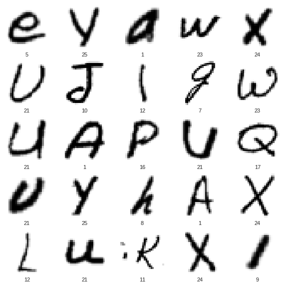

```python
plt.figure(figsize=(10,10))
for i in range(25):
    plt.subplot(5,5,i+1)
    plt.xticks([])
    plt.yticks([])
    plt.imshow(train_images[i].T, cmap=plt.cm.binary)
    plt.xlabel(train_labels[i])
    plt.grid(False)

plt.show()
```

```python
#Переведем значения в шкалу от 0 до 1:
train_images = train_images / 255.0
test_images = test_images / 255.0
```

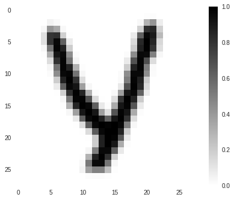

```python
plt.figure()
plt.imshow(train_images[1].T, cmap='gray_r')
plt.colorbar()
plt.grid(False)
plt.show()
```

Начнем с построения однослойной сети без скрытых слоев

```python
linear_model = keras.Sequential([
    keras.layers.Flatten(input_shape=(28, 28)), # перевод данных в вектор
    #размерности 28*28=784 (построчно)
    keras.layers.Dense(27, activation=tf.nn.softmax) # 27 - число классов
])
```

```python
linear_model.compile(optimizer=tf.train.GradientDescentOptimizer(learning_rate=0.01),
                     loss='sparse_categorical_crossentropy',
                     metrics=['accuracy'])
```

```python
linear_model.fit(train_images, train_labels, epochs=10)
```

```
<tensorflow.python.keras.callbacks.History at 0x7f4b64758c18>
```

```python
test_loss, test_acc = linear_model.evaluate(test_images, test_labels)
```

```python
print('Test accuracy:', test_acc, '\nTest loss:', test_loss)
```

```
Test accuracy: 0.6867692307692308
Test loss: 1.105703591786898
```

Мы можем свернуть вектор весов в картинку 28×28 и провизуализировать:

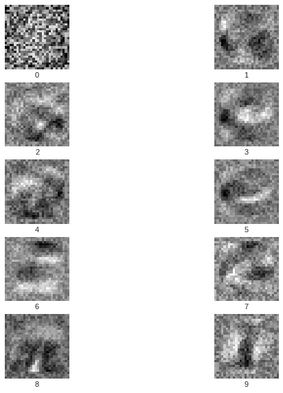

```python
plt.figure(figsize=(10,10))
for i in range(10):
    plt.subplot(5,2,i+1)
    plt.xticks([])
    plt.yticks([])
    plt.imshow(linear_model.get_layer(index=1).get_weights()[0][:, i].reshape((28, 28)).T * -1, cmap='gray')
    plt.xlabel(i)
    plt.grid(False)

plt.show()
```

```python
#plot_cm = files.upload()
```

```python
from sklearn import metrics

#from plot_cm import plot_confusion_matrix
```

```python
def plot_confusion_matrix(cm,
                          target_names,
                          title='Confusion matrix',
                          cmap=None,
                          normalize=True):
    """
    given a sklearn confusion matrix (cm), make a nice plot

    Arguments
    ---------
    cm:           confusion matrix from sklearn.metrics.confusion_matrix

    target_names: given classification classes such as [0, 1, 2]
                  the class names, for example: ['high', 'medium', 'low']

    title:        the text to display at the top of the matrix

    cmap:         the gradient of the values displayed from matplotlib.pyplot.cm
                  see http://matplotlib.org/examples/color/colormaps_reference.html
                  plt.get_cmap('jet') or plt.cm.Blues

    normalize:    If False, plot the raw numbers
                  If True, plot the proportions

    Usage
    -----
    plot_confusion_matrix(cm           = cm,                  # confusion matrix created by
                                                              # sklearn.metrics.confusion_matrix
                          normalize    = True,                # show proportions
                          target_names = y_labels_vals,       # list of names of the classes
                          title        = best_estimator_name) # title of graph

    Citiation
    ---------
    http://scikit-learn.org/stable/auto_examples/model_selection/plot_confusion_matrix.html

    """
    import matplotlib.pyplot as plt
    import numpy as np
    import itertools

    accuracy = np.trace(cm) / float(np.sum(cm))
    misclass = 1 - accuracy

    if cmap is None:
        cmap = plt.get_cmap('Blues')

    plt.figure(figsize=(20, 15))
    plt.imshow(cm, interpolation='nearest', cmap=cmap)
    plt.title(title)
    plt.colorbar()

    if target_names is not None:
        tick_marks = np.arange(len(target_names))
        plt.xticks(tick_marks, target_names, rotation=45)
        plt.yticks(tick_marks, target_names)

    if normalize:
        cm = cm.astype('float') / cm.sum(axis=1)[:, np.newaxis]


    thresh = cm.max() / 1.5 if normalize else cm.max() / 2
    for i, j in itertools.product(range(cm.shape[0]), range(cm.shape[1])):
        if normalize:
            plt.text(j, i, "{:0.4f}".format(cm[i, j]),
                     horizontalalignment="center",
                     color="white" if cm[i, j] > thresh else "black")
        else:
            plt.text(j, i, "{:,}".format(cm[i, j]),
                     horizontalalignment="center",
                     color="white" if cm[i, j] > thresh else "black")


    plt.tight_layout()
    plt.ylabel('True label')
    plt.xlabel('Predicted label\naccuracy={:0.4f}; misclass={:0.4f}'.format(accuracy, misclass))
    plt.show()
```

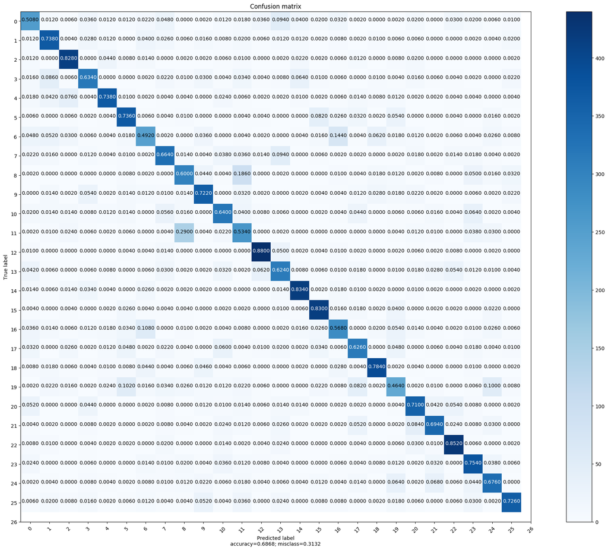

```python
style.use('default')
plot_confusion_matrix(cm=metrics.confusion_matrix(test_labels, linear_model.predict_classes(test_images)),
                      target_names=np.arange(0, 27),
                      normalize=True)
```

```python
%%time

linear_model = keras.Sequential([
    keras.layers.Flatten(input_shape=(28, 28)), # перевод данных в вектор размерности 28*28=784 (построчно)
    keras.layers.Dense(27, activation=tf.nn.softmax) # 27 - число классов
])

linear_model.compile(optimizer=tf.train.GradientDescentOptimizer(learning_rate=0.01),
                     loss='sparse_categorical_crossentropy',
                     metrics=['accuracy'])

linear_model.fit(train_images, train_labels, epochs=100, verbose=0)
```

```
CPU times: user 5min 9s, sys: 12.1 s, total: 5min 21s
Wall time: 3min 48s
```

```python
test_loss, test_acc = linear_model.evaluate(test_images, test_labels)
print('Test accuracy:', test_acc, '\nTest loss:', test_loss)
```

```
Test accuracy: 0.7091538461538461
Test loss: 1.0316624824817364
```

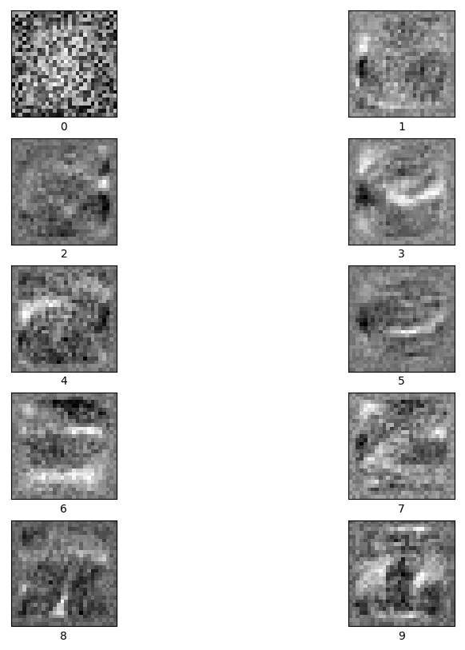

```python
plt.figure(figsize=(10,10))
for i in range(10):
    plt.subplot(5,2,i+1)
    plt.xticks([])
    plt.yticks([])
    plt.imshow(linear_model.get_layer(index=1).get_weights()[0][:, i].reshape((28, 28)).T, cmap='gray_r')
    plt.xlabel(i)
    plt.grid(False)

plt.show()
```

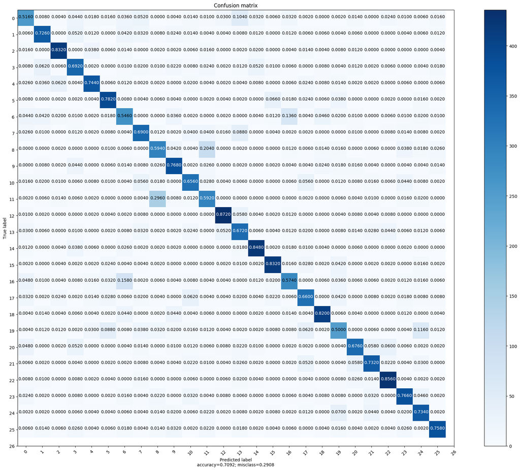

```python
style.use('default')
plot_confusion_matrix(cm=metrics.confusion_matrix(test_labels, linear_model.predict_classes(test_images)),
                      target_names=np.arange(0, 27),
                      normalize=True)
```

Перейдем к созданию многослойной нейросети. Добавим один скрытый слой из 100 нейронов в модель

```python
linear_model = keras.Sequential()

linear_model.add(keras.layers.Flatten(input_shape=(28, 28))) # перевод данных в вектор размерности 28*28=784 (построчно)

linear_model.add(keras.layers.Dense(100)) # скрытый слой из 100 нейронов
linear_model.add(keras.layers.Activation('relu')) # функция активации

linear_model.add(keras.layers.Dense(27, activation=tf.nn.softmax)) # 27 - число классов
```

```python
linear_model.compile(optimizer=keras.optimizers.SGD(lr=0.01),
                     loss='sparse_categorical_crossentropy',
                     metrics=['accuracy'])
```

```python
linear_model.fit(train_images, train_labels, epochs=10, verbose=0)
```

```
<tensorflow.python.keras.callbacks.History at 0x7f4b649210f0>
```

```python
test_loss, test_acc = linear_model.evaluate(test_images, test_labels)
print('Test accuracy:', test_acc, '\nTest loss:', test_loss)
```

```
Test accuracy: 0.8161538461538461
Test loss: 0.6412181143760681
```

Test accuracy: 0.8161538461538461 Test loss: 0.6412181143760681

```python
len(linear_model.layers)
```

```
4
```

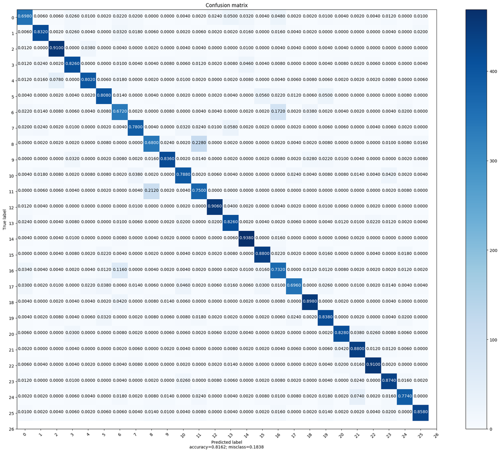

```python
plot_confusion_matrix(cm=metrics.confusion_matrix(test_labels, linear_model.predict_classes(test_images)),
                      target_names=np.arange(0, 27),
                      normalize=True)
```

Провизуализируем веса первого скрытого слоя (который связан с входным)

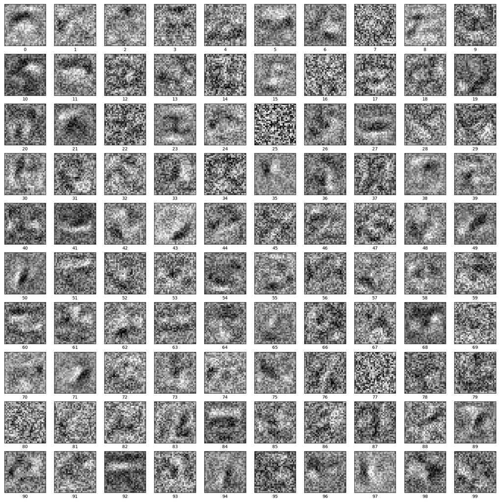

```python
plt.figure(figsize=(20, 20))
for i in range(100):
    plt.subplot(10,10,i+1)
    plt.xticks([])
    plt.yticks([])
    plt.imshow(linear_model.get_layer(index=1).get_weights()[0][:, i].reshape((28, 28)).T, cmap='gray_r')
    plt.xlabel(i)
    plt.grid(False)

plt.show()
```

```python
df = pd.DataFrame(linear_model.get_layer(index=3).get_weights()[0][:,4].reshape(10,10).round(3))
df.style.background_gradient(cmap='coolwarm')
```

|  | 0 | 1 | 2 | 3 | 4 | 5 | 6 | 7 | 8 | 9 |
| --- | --- | --- | --- | --- | --- | --- | --- | --- | --- | --- |
| 0 | 0.598 | -0.442 | -0.184 | 0.292 | -0.062 | -0.032 | 0.001 | -0.316 | -0.001 | -0.249 |
| 1 | -0.166 | 0.149 | -0.102 | 0.257 | 0.057 | -0.16 | -0.061 | 0.299 | -0.281 | -0.151 |
| 2 | 0.357 | 0.081 | 0.197 | 0.043 | 0.177 | 0.139 | -0.057 | -0.181 | -0.054 | -0.143 |
| 3 | 0.11 | -0.023 | 0.176 | 0.02 | -0.148 | -0.239 | 0.22 | -0.021 | -0.335 | -0.07 |
| 4 | 0.116 | -0.555 | 0.087 | 0.14 | -0.06 | 0.036 | -0.259 | -0.071 | 0.227 | 0.042 |
| 5 | 0.147 | 0.008 | -0.132 | 0.031 | -0.095 | 0.18 | -0.24 | -0.047 | 0.053 | -0.288 |
| 6 | -0.339 | 0.025 | -0.238 | -0.06 | -0.287 | 0.318 | 0.063 | -0.447 | -0.296 | -0.192 |
| 7 | 0.204 | 0.057 | 0.181 | 0.061 | -0.247 | -0.233 | 0.029 | -0.113 | 0.027 | 0.206 |
| 8 | -0.249 | 0.125 | -0.029 | 0.052 | 0.341 | -0.04 | 0.205 | 0.329 | -0.318 | 0.713 |
| 9 | -0.063 | -0.302 | 0.405 | -0.299 | 0.491 | -0.05 | -0.034 | -0.128 | 0.429 | 0.284 |

```python
from tensorflow import keras
from tensorflow.keras.models import Sequential
from tensorflow.keras.layers import Dense, Flatten
from tensorflow.keras.optimizers import SGD
```

```python
ann_model = Sequential(
    [
        Flatten(input_shape=(28, 28)),  # перевод данных в вектор размерности 28*28=784 (построчно)
        Dense(100, activation='relu',
              kernel_initializer='glorot_uniform', bias_initializer='zeros'),  # скрытый слой из 100 нейронов
        Dense(27, activation='softmax',
              kernel_initializer='glorot_uniform', bias_initializer='zeros') # выходной слой из 27 нейронов по числу классов
    ]
)

ann_model.compile(optimizer=SGD(lr=0.1),
                  loss='sparse_categorical_crossentropy',
                  metrics=['accuracy'])
```

```python
%%time
ann_model.fit(train_images, train_labels, epochs=10, verbose=1)
```

```
CPU times: user 58 s, sys: 3.94 s, total: 1min 1s
Wall time: 44.4 s
```

```
<tensorflow.python.keras.callbacks.History at 0x7f4b90d6def0>
```

```python
test_loss, test_acc = ann_model.evaluate(test_images, test_labels)
print('Test accuracy:', test_acc, '\nTest loss:', test_loss)
```

```
Test accuracy: 0.8697692307692307
Test loss: 0.4330670485496521
```

if optimizer=SGD(lr=0.01):

Test accuracy: 0.80915385 Test loss: 0.6538339856954721

if optimizer=SGD(lr=0.001):

Test accuracy: 0.6463846 Test loss: 1.2411210293403039

if optimizer=SGD(lr=0.1):

Test accuracy: 0.8550769 Test loss: 0.46781429701585037

Изменим оптимайзер на RMSprop:

```python
ann_model = Sequential(
    [
        Flatten(input_shape=(28, 28)),  # перевод данных в вектор размерности 28*28=784 (построчно)
        Dense(100, activation='relu',
              kernel_initializer='glorot_uniform', bias_initializer='zeros'),  # скрытый слой из 100 нейронов
        Dense(27, activation='softmax',
              kernel_initializer='glorot_uniform', bias_initializer='zeros') # выходной слой из 27 нейронов по числу классов
    ]
)

ann_model.compile(optimizer=RMSprop(lr=0.1),
                  loss='sparse_categorical_crossentropy',
                  metrics=['accuracy'])
```

```python
%%time
ann_model.fit(train_images, train_labels, epochs=10, verbose=1)
test_loss, test_acc = ann_model.evaluate(test_images, test_labels)
print('Test accuracy:', test_acc, '\nTest loss:', test_loss)
```

```
Test accuracy: 0.038461538461538464
Test loss: 15.498170407221867
CPU times: user 1min 20s, sys: 5.51 s, total: 1min 26s
Wall time: 59.7 s
```

Test accuracy: 0.038461538461538464 Test loss: 15.498170407221867

Все очень и очень печально :С

Больше так делать не будем.

Добавим 3 слой:

```python
from tensorflow.keras import regularizers
from tensorflow.keras.layers import BatchNormalization, Activation
```

```python
ann_model = Sequential(
    [
        Flatten(input_shape=(28, 28)),  # перевод данных в вектор размерности 28*28=784 (построчно)

        Dense(100,
              kernel_regularizer=regularizers.l2(0.00)),  # скрытый слой из 100 нейронов
        BatchNormalization(),
        Activation('relu'),

        Dense(50,
              kernel_regularizer=regularizers.l2(0.00)),  # скрытый слой из 50 нейронов
        BatchNormalization(),
        Activation('relu'),

        Dense(27, activation='softmax') # выходной слой из 27 нейронов по числу классов
    ]
)

ann_model.compile(optimizer=SGD(lr=0.01),
                  loss='sparse_categorical_crossentropy',
                  metrics=['accuracy'])
```

```python
%%time
ann_model.fit(train_images, train_labels, epochs=10, verbose=0)

test_loss, test_acc = ann_model.evaluate(test_images, test_labels)
print('\nTest accuracy:', test_acc, '\nTest loss:', test_loss, '\n')
```

```
Test accuracy: 0.8704615384615385
Test loss: 0.41203949482624347

CPU times: user 1min 12s, sys: 3.7 s, total: 1min 16s
Wall time: 47.7 s
```

if optimizer=SGD(lr=0.01):

Test accuracy: 0.87346154 Test loss: 0.40630391981051517

if optimizer=SGD(lr=0.1):

Test accuracy: 0.8726154 Test loss: 0.39360170340538025

if optimizer=SGD(lr=0.001):

Test accuracy: 0.73615384 Test loss: 0.9568838689510639

With using optimizers

```python
from tensorflow.keras.optimizers import RMSprop, Adam
```

```python
ann_model = Sequential(
    [
        Flatten(input_shape=(28, 28)),  # перевод данных в вектор размерности 28*28=784 (построчно)

        Dense(100),  # скрытый слой из 100 нейронов
        BatchNormalization(),
        Activation('relu'),

        Dense(50),  # скрытый слой из 50 нейронов
        BatchNormalization(),
        Activation('relu'),

        Dense(27, activation='softmax') # выходной слой из 27 нейронов по числу классов
    ]
)

ann_model.compile(optimizer=Adam(lr=0.01),
                  loss='sparse_categorical_crossentropy',
                  metrics=['accuracy'])
```

```python
%%time
ann_model.fit(train_images, train_labels, epochs=10, verbose=0)

test_loss, test_acc = ann_model.evaluate(test_images, test_labels)
print('\nTest accuracy:', test_acc, '\nTest loss:', test_loss, '\n')
```

```
Test accuracy: 0.8906923076923077
Test loss: 0.34892192524213056

CPU times: user 1min 44s, sys: 6.01 s, total: 1min 50s
Wall time: 1min 7s
```

If optimizer=Adam(lr=0.0001):

Test accuracy: 0.85992306 Test loss: 0.4521610068357908

if optimizer=Adam(lr=0.01):

Test accuracy: 0.89484614 Test loss: 0.33572903247979974

if optimizer=Adam(lr=0.1)

Test accuracy: 0.832 Test loss: 0.5575880073033846

Попробуем изменить количество нейронов:

```python
ann_model = Sequential(
    [
        Flatten(input_shape=(28, 28)),  # перевод данных в вектор размерности 28*28=784 (построчно)

        Dense(250),  # скрытый слой из 250 нейронов
        BatchNormalization(),
        Activation('relu'),

        Dense(100),  # скрытый слой из 100 нейронов
        BatchNormalization(),
        Activation('relu'),

        Dense(27, activation='softmax') # выходной слой из 27 нейронов по числу классов
    ]
)

ann_model.compile(optimizer=Adam(lr=0.01),
                  loss='sparse_categorical_crossentropy',
                  metrics=['accuracy'])
```

```python
%%time
ann_model.fit(train_images, train_labels, epochs=10, verbose=0)

test_loss, test_acc = ann_model.evaluate(test_images, test_labels)
print('\nTest accuracy:', test_acc, '\nTest loss:', test_loss, '\n')
```

```
Test accuracy: 0.8983076923076924
Test loss: 0.3291689691085082

CPU times: user 3min 10s, sys: 12.2 s, total: 3min 23s
Wall time: 2min 1s
```

При изменении скрытых слоев на 250 и 100 нейронов:

Test accuracy: 0.9042308 Test loss: 0.31886855688003396

Попробуем изменить количество скрытых слоев. Добавим еще один скрытый слой.

```python
ann_model = Sequential(
    [
        Flatten(input_shape=(28, 28)),  # перевод данных в вектор размерности 28*28=784 (построчно)

        Dense(250),  # скрытый слой из 250 нейронов
        BatchNormalization(),
        Activation('relu'),

        Dense(100),  # скрытый слой из 100 нейронов
        BatchNormalization(),
        Activation('relu'),

        Dense(50),  # скрытый слой из 50 нейронов
        BatchNormalization(),
        Activation('relu'),

        Dense(27, activation='softmax') # выходной слой из 27 нейронов по числу классов
    ]
)

ann_model.compile(optimizer=Adam(lr=0.01),
                  loss='sparse_categorical_crossentropy',
                  metrics=['accuracy'])
```

```python
%%time
ann_model.fit(train_images, train_labels, epochs=10, verbose=0)

test_loss, test_acc = ann_model.evaluate(test_images, test_labels)
print('\nTest accuracy:', test_acc, '\nTest loss:', test_loss, '\n')
```

```
Test accuracy: 0.9036923076923077
Test loss: 0.30748217854591514

CPU times: user 3min 39s, sys: 14.1 s, total: 3min 53s
Wall time: 2min 21s
```

Test accuracy: 0.9036923076923077 Test loss: 0.30748217854591514

Добавим dropout дабы избежать переобучения. Посмотрим, что выйдет:

```python
from tensorflow.keras.layers import Dropout
```

```python
ann_model = Sequential(
    [
        Flatten(input_shape=(28, 28)),  # перевод данных в вектор размерности 28*28=784 (построчно)

        Dense(1000),  # скрытый слой из 100 нейронов
        BatchNormalization(),
        Activation('relu'),
        Dropout(0.5),

        Dense(500),  # скрытый слой из 50 нейронов
        BatchNormalization(),
        Activation('relu'),
        Dropout(0.5),

        Dense(27, activation='softmax') # выходной слой из 27 нейронов по числу классов
    ]
)

ann_model.compile(optimizer=Adam(lr=0.01),
                  loss='sparse_categorical_crossentropy',
                  metrics=['accuracy'])
```

```python
%%time
ann_model.fit(train_images, train_labels, epochs=50, verbose=1)

test_loss, test_acc = ann_model.evaluate(test_images, test_labels)
print('\nTest accuracy:', test_acc, '\nTest loss:', test_loss, '\n')
```

```
Test accuracy: 0.9083846153846153
Test loss: 0.27585744639543386

CPU times: user 1h 14min 13s, sys: 4min 1s, total: 1h 18min 15s
Wall time: 44min 29s
```

Test accuracy: 0.9083846153846153 Test loss: 0.27585744639543386

Изменим оптимайзер на RMSprop:

```python
ann_model = Sequential(
    [
        Flatten(input_shape=(28, 28)),  # перевод данных в вектор размерности 28*28=784 (построчно)

        Dense(500),  # скрытый слой из 500 нейронов
        BatchNormalization(),
        Activation('relu'),
        Dropout(0.5),

        Dense(250),  # скрытый слой из 250 нейронов
        BatchNormalization(),
        Activation('relu'),
        Dropout(0.5),

        Dense(27, activation='softmax') # выходной слой из 27 нейронов по числу классов
    ]
)

ann_model.compile(optimizer=RMSprop(lr=0.01),
                  loss='sparse_categorical_crossentropy',
                  metrics=['accuracy'])
```

```python
%%time
ann_model.fit(train_images, train_labels, epochs=50, verbose=1)

test_loss, test_acc = ann_model.evaluate(test_images, test_labels)
print('\nTest accuracy:', test_acc, '\nTest loss:', test_loss, '\n')
```

```
Test accuracy: 0.7096153846153846
Test loss: 0.9856200860830454

CPU times: user 29min 32s, sys: 2min 6s, total: 31min 39s
Wall time: 19min 32s
```

Test accuracy: 0.7096153846153846 Test loss: 0.9856200860830454

Попробуем создать сверточную нейронную сеть и посмотреть, как она будет себя показывать на тестовых данных:

```python
from keras.layers import Dense, Conv2D, Dropout, Flatten, MaxPooling2D, Activation
from tensorflow.keras.optimizers import RMSprop, Adam
from keras.models import Sequential
```

```python
cnn_model = Sequential(
    [
        Conv2D(28, kernel_size=(3,3), input_shape=(28, 28, 1)),
        MaxPooling2D(pool_size=(2, 2)),
        Flatten(), #Flattening(сглаживание?) 2D массивов для полностью связанных слоев

        Dense(250), # скрытый слой из 250 нейронов
        Activation('relu'),
        Dropout(0.3),

        Dense(100), # скрытый слой из 100 нейронов
        Activation('relu'),
        Dropout(0.3),

        Dense(27), # выходной слой из 27 нейронов по числу классов
        Activation('softmax')
    ]
)

cnn_model.compile(optimizer='adam',
                  loss='sparse_categorical_crossentropy',
                  metrics=['accuracy'])
```

```python
from tensorflow.keras.models import Sequential
from tensorflow.keras.layers import Dense, Flatten
from tensorflow.keras.optimizers import SGD
```

```python
%%time

cnn_model.fit(train_images.reshape(65000, 28, 28, 1), train_labels, epochs=25, verbose=1)
```

```
CPU times: user 53min 40s, sys: 1min 52s, total: 55min 33s
Wall time: 31min 56s
```

```
<keras.callbacks.History at 0x7f4b5619ccc0>
```

```python
test_loss, test_acc = cnn_model.evaluate(test_images.reshape(13000, 28, 28, 1), test_labels)
print('\nTest accuracy:', test_acc, '\nTest loss:', test_loss, '\n')
```

```
Test accuracy: 0.9176153846153846
Test loss: 0.30082153021716157
```

If dropout(0.3) and number of epoch == 10:

Test accuracy: 0.917923076923077 Test loss: 0.26045440377180396

if dropout(0.4) and number of epoch == 25:

Test accuracy: 0.9034615384615384 Test loss: 0.3367046816142706

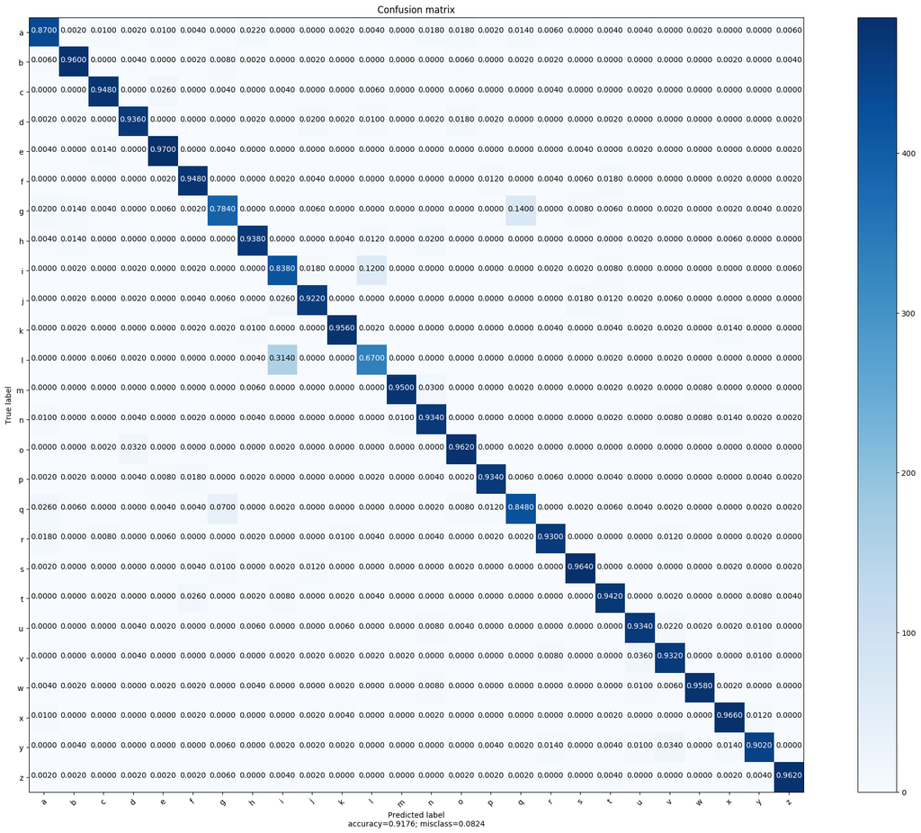

```python
AL = 'abcdefghijklmnopqrstuvwxyz'
plot_confusion_matrix(cm=metrics.confusion_matrix(test_labels, cnn_model.predict_classes(test_images.reshape(13000, 28, 28, 1))),
                      target_names=AL,
                      normalize=True)
```

Наилучшая модель получилась - свертка. Точность - 91%

Пары букв, которые чаще всего путаются между собой:

L - I

O - D

Q - G

Q - A

T - F

J - I

V - U

Y - V

P - F

E - C

Буквы с лучшим процентом детекции:

E - 97%

Буквы с худшим процентом:

L - 67%

G - 78.4%

```
(28, 28)
```

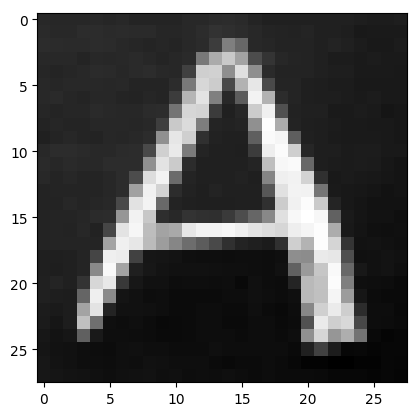

```
array([1])
```

```python
import matplotlib.image as mpimg

#uploaded = files.upload()

def rgb2gray(rgb):
    return np.dot(rgb[...,:3], [0.299, 0.587, 0.114])

my_img = np.empty(shape=(5,28,28))

#img_a = mpimg.imread(io.BytesIO(uploaded['A.png']))
img_a = mpimg.imread('A (2).png')


img_a = 1 - img_a
gray=rgb2gray(img_a)
plt.imshow(gray, cmap='gray')
print(gray.shape)
plt.show()

cnn_model.predict_classes(gray.T.reshape(1,28,28,1))
```

```
(28, 28)
```

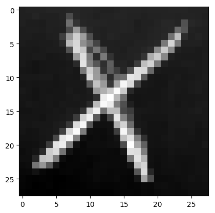

```
array([24])
```

```python
import matplotlib.image as mpimg

#uploaded = files.upload()

def rgb2gray(rgb):
    return np.dot(rgb[...,:3], [0.299, 0.587, 0.114])

my_img = np.empty(shape=(5,28,28))

#img_x = mpimg.imread(io.BytesIO(uploaded['X.png']))
img_x = mpimg.imread('X.png')

img_x = 1 - img_x
gray=rgb2gray(img_x)
plt.imshow(gray, cmap='gray')
print(gray.shape)
plt.show()

cnn_model.predict_classes(gray.T.reshape(1,28,28,1))
```

```
(28, 28)
```

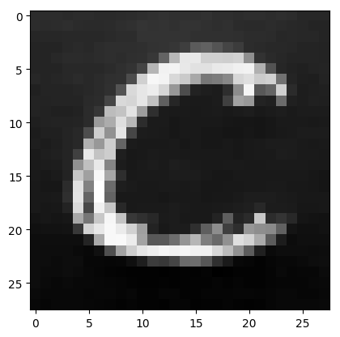

```
array([3])
```

```python
import matplotlib.image as mpimg

#uploaded = files.upload()

def rgb2gray(rgb):
    return np.dot(rgb[...,:3], [0.299, 0.587, 0.114])

my_img = np.empty(shape=(5,28,28))

#img_c = mpimg.imread(io.BytesIO(uploaded['C.png']))
img_c = mpimg.imread('C.png')

img_c = 1 - img_c
gray=rgb2gray(img_c)
plt.imshow(gray, cmap='gray')
print(gray.shape)
plt.show()

cnn_model.predict_classes(gray.T.reshape(1,28,28,1))
```

```
(28, 28)
```

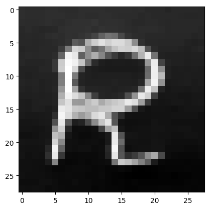

```
array([18])
```

```python
import matplotlib.image as mpimg

#uploaded = files.upload()

def rgb2gray(rgb):
    return np.dot(rgb[...,:3], [0.299, 0.587, 0.114])

my_img = np.empty(shape=(5,28,28))

#img_r = mpimg.imread(io.BytesIO(uploaded['R.png']))
img_r = mpimg.imread('R.png')

img_r = 1 - img_r
gray=rgb2gray(img_r)
plt.imshow(gray, cmap='gray')
print(gray.shape)
plt.show()

cnn_model.predict_classes(gray.T.reshape(1,28,28,1))
```

```
(28, 28)
```

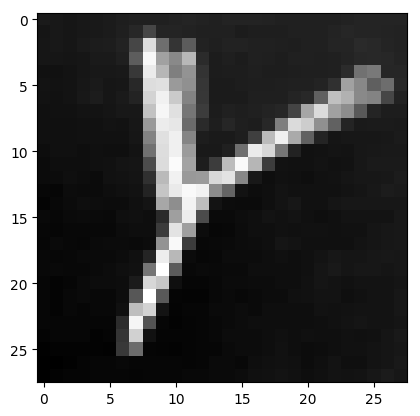

```
array([18])
```

```python
import matplotlib.image as mpimg

#uploaded = files.upload()

def rgb2gray(rgb):
    return np.dot(rgb[...,:3], [0.299, 0.587, 0.114])

my_img = np.empty(shape=(5,28,28))

#img_y = mpimg.imread(io.BytesIO(uploaded['Y.png']))
img_y = mpimg.imread('Y.png')
img_y = 1 - img_y
gray=rgb2gray(img_y)
plt.imshow(gray, cmap='gray')
print(gray.shape)
plt.show()

cnn_model.predict_classes(gray.T.reshape(1,28,28,1))
```